# Weekend homework week 6

# 1.1 Hypothesis testing - practical

You work for an animal conservation organisation and are looking to do some investigating into some of the animals to provide evidence for some projects you are looking to run.

In this homework we’ll use the **msleep** data set provided in the ggplot package. It concerns the sleeping patterns of various types of mammal.

```r
library(tidyverse)
library(infer)
data(msleep)
```

```r
msleep <- msleep
```

## 1.1.1 Explore the dataset and familiarise yourself with it

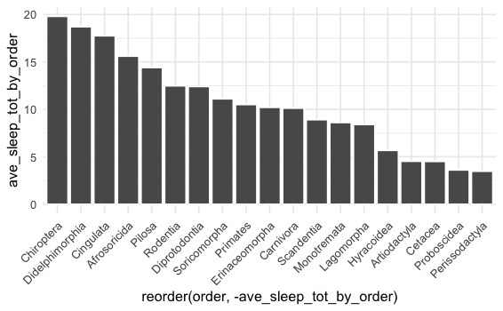

```r
msleep %>%
  group_by(order) %>%
  summarise(ave_sleep_tot_by_order = mean(sleep_total)) %>%
  ggplot(aes(x = reorder(order, -ave_sleep_tot_by_order), y = ave_sleep_tot_by_order)) +
  theme_minimal() +

  theme(axis.text.x = element_text(angle = 45, hjust = 1)) +
  geom_col(col = "white")
```

```
Ignoring unknown parameters: scales
```

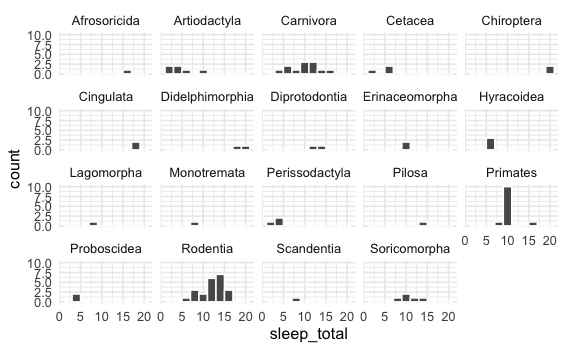

```r
msleep %>%
  ggplot() +
  aes(x = sleep_total) +
  geom_histogram(col = "white", bins = 10, scales = "free_y") +
  theme_minimal() +
  #facet_wrap(~vore)
  facet_wrap(~order)
```

```r
NA
```

## 1.1.2 Jabberwockies

Jabberwockies sleep for around 7 hours a night, on average. Perform an appropriate statistical test to determine whether the mean sleep_total in the sampled population of animal types differs from the typical value for jabberwockies.

**Need to test:** is there a statistically significant difference between the average sleep time of jabberwockies, and the average sleep time calculated accross all animals in the sample data

**How I’m doing this:** not sure this is right, but:

- Using the msleep data, I’ll use bootstrap to create what a normal distribution would look like if the mean sleep time for all animals was 7, the same as for jabberwockies.
- I’ll then put the actual “all animals” mean onto this distribution, and see if it is significantly different from 7.

```r
observed_stat_jabberwockies <- 7
```

### i get all animals mean sleep total

```r
observed_stat_all_animals  <- msleep %>%
  summarise(mean_sleep_total = mean(sleep_total))

observed_stat_all_animals
```

| mean_sleep_total |
| --- |
| 10.43373 |

### ii bootstrap a normal distribution where average sleep total is 7

[output not shown]

[output cut: 990 more lines]

### iii visualise normal distribution, overlain with observed mean sleep total for all animals

[figure not shown]

```r
null_distribution_all_animals %>%
  visualise(bins = 30) +
  shade_p_value(obs_stat = observed_stat_all_animals$mean_sleep_total,
                direction = "both")
```

### iv calculate p value

By this method, there is only a tiny chance that the observed all animals mean of 10.4 hours could occur in a normal distribution where the mean sleep hours is 7

```r
p_value <- null_distribution_all_animals %>%
  get_p_value(obs_stat = observed_stat_all_animals$mean_sleep_total,
              direct = "both")
```

```
Please be cautious in reporting a p-value of 0. This result is an approximation based on the number of `reps` chosen in the `generate()` step. See `?get_p_value()` for more information.
```

```r
p_value
```

| p_value |
| --- |
| 0 |

## 1.1.3 Perform an appropriate statistical test to determine whether omnivores sleep for significantly longer than herbivores, on average.

check data:

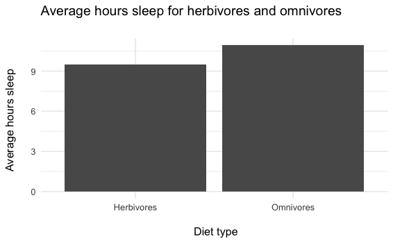

```r
msleep %>%
  filter(vore %in% c("omni", "herbi")) %>%
  mutate(diet  = recode(vore,
                        "omni" = "Omnivores",
                        "herbi" = "Herbivores")
  ) %>%
  group_by(diet) %>%
  summarise(average_hours_sleep = mean(sleep_total)) %>%
  ggplot() +
  aes(x = diet, y = average_hours_sleep) +
  theme_minimal() +
  geom_col() +
  labs(
    title = "Average hours sleep for herbivores and omnivores \n",
    x = "\n Diet type",
    y = "Average hours sleep \n"
  )
```

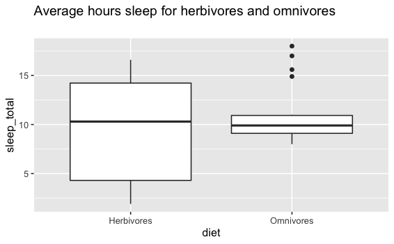

```r
msleep %>%
  filter(vore %in% c("omni", "herbi")) %>%
  mutate(diet  = recode(vore,
                        "omni" = "Omnivores",
                        "herbi" = "Herbivores")
  ) %>%
  ggplot() +
  aes(x = diet, y = sleep_total) +
  geom_boxplot() +
  labs(
    title = "Average hours sleep for herbivores and omnivores \n"
  )
```

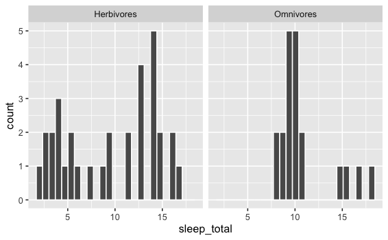

```r
msleep %>%
  filter(vore %in% c("omni", "herbi")) %>%
  mutate(diet  = recode(vore,
                        "omni" = "Omnivores",
                        "herbi" = "Herbivores")
  ) %>%
  ggplot() +
  aes(x =  sleep_total) +
  geom_histogram(col= "white", bins = 25) +
  facet_wrap(~diet)
```

### Hypothesis:

H0: μsleep_total(omnivores)−μsleep_total(herbivores) = 0

Ha: μsleep_total(omnivores)−μsleep_total(herbivores) > 0

### i null distribution

```r
null_distribution_omni_herbi <- msleep %>%
  filter(vore %in% c("omni", "herbi")) %>%
  mutate(diet  = recode(vore,
                        "omni" = "omnivore",
                        "herbi" = "herbivore")
         ) %>%
  specify(response = sleep_total, explanatory = diet) %>%
  hypothesise(null = "independence") %>%
  generate(reps = 1000, type = "permute") %>%
  calculate(stat = "diff in means", order = c("omnivore", "herbivore"))

head(null_distribution_omni_herbi)
```

| replicate | stat |
| --- | --- |
| 1 | -0.103750 |
| 2 | -1.387500 |
| 3 | 1.326250 |
| 4 | -1.265625 |
| 5 | -1.826250 |
| 6 | 1.228750 |

### ii observed statistic

```r
observed_stat_omni_herbi <- msleep %>%
  filter(vore %in% c("omni", "herbi")) %>%
  mutate(diet  = recode(vore,
                        "omni" = "omnivore",
                        "herbi" = "herbivore")
         ) %>%
  specify(sleep_total ~ diet) %>%
  calculate(stat = "diff in means", order = c("omnivore", "herbivore"))

observed_stat_omni_herbi
```

| stat |
| --- |
| 1.415625 |

### iii put observed stat onto null distribution

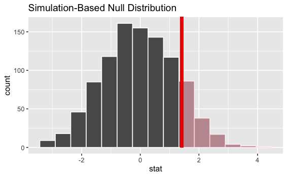

```r
null_distribution_omni_herbi %>%
  visualise() +
  shade_p_value(obs_stat = observed_stat_omni_herbi, direction = "greater")
```

### iv calculate p value

```r
p_value_omni_herbi <- null_distribution_omni_herbi %>%
  get_p_value(obs_stat = observed_stat_omni_herbi, direction = "greater")

p_value_omni_herbi
```

| p_value |
| --- |
| 0.125 |

### v is this significant?

Not sure - not even sure my calculations are correct or doing the right things!

Think it’s telling me they’re not significantly different - if I was setting a alpha of 0.05, the p value is greater than this; so I can’t reject my null hypothesis.